# JO (eLinks) Integration — RAM ER Diagram

Source system: **Judicial Office eLinks** (backed by JHR — Judicial HR). All RAM tables that hold a replicated copy of eLinks data use the `jo_` prefix. The full column-level source→RAM mapping is in the companion page **JO (eLinks) Integration — RAM Schema & Source Mapping**.

## Conventions

- **Transactional** tables: person and the things owned by a person (appointments, judiciary role assignments, authorisations).
- **Reference** tables: lookup data refreshed from the `/reference_data/*` endpoints.
- All reference and many transactional rows carry the source’s own integer `id` — RAM preserves that as the primary key so foreign keys keep working across refreshes (the source guarantees these `id`s are stable across releases and environments).
- `jo_people` is keyed by `personal_code` — the only attribute the source guarantees is unique and never reused (do **not** key on `id`, `email` or `per_id`).
- Deprecated source attributes (`per_id`, `sex`, the old flat `authorisations` array) are excluded.

## Naming clash — note

The source has a transactional `judiciary_roles[]` array on `/people` **and** a reference endpoint `/reference_data/judiciary_roles`. To avoid a table-name clash in RAM:

| Source | RAM table |
| --- | --- |
| `people.judiciary_roles[]` (transactional assignment) | `jo_judiciary_role_assignments` |
| `/reference_data/judiciary_roles` (lookup) | `jo_judiciary_roles` |

This is the only deviation from a strict 1:1 source→RAM name mapping.

## Sync metadata

Per the agreed approach, refresh-status columns (`last_synced_at`, page cursor, last error, etc.) live in a **single side table** `jo_sync_status` keyed by source endpoint — they are not duplicated on every functional table. Source-provided `created_at` / `updated_at` are kept on the tables that the source exposes them on, because they describe the source row (not RAM’s sync).

## Transactional core

For day-to-day queries against JOH data, this is the most useful slice — `jo_people` and its direct children, plus the person/appointment lookups:

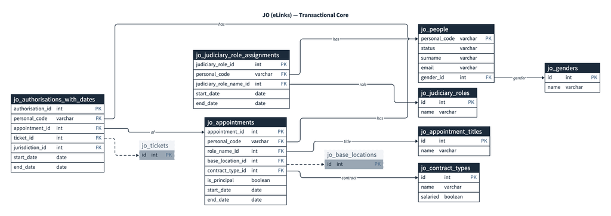

Transactional core ER diagram

## Location cluster

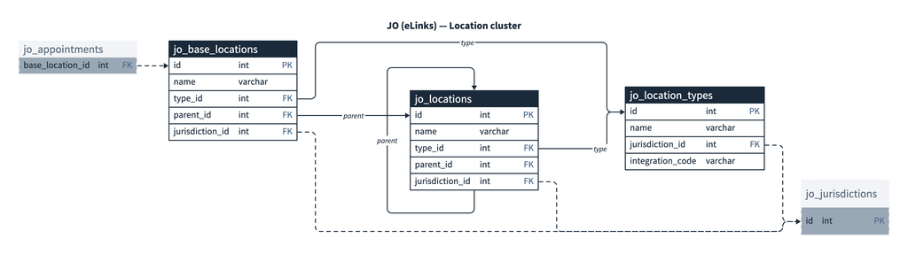

Location cluster ER diagram

## Ticket cluster

The Courts edge case — an authorisation’s `jurisdiction_id` points at a `jo_ticket_categories` row rather than a `jo_jurisdictions` row — is shown by the dashed “when Courts” edge:

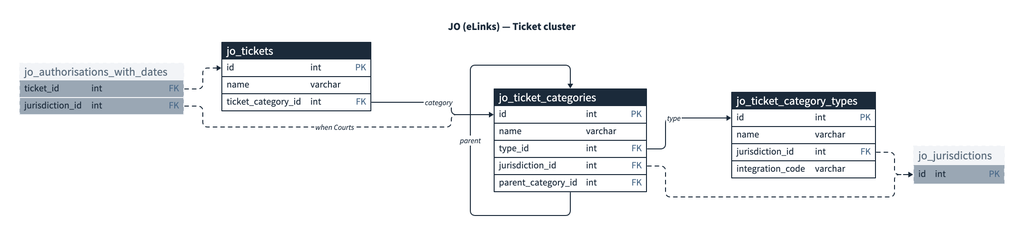

Ticket cluster ER diagram

## Reference hub — jurisdictions & sync

`jo_jurisdictions` is the shared lookup every cluster points back to. `jo_sync_status` has no foreign keys — it tracks refresh state, one row per source endpoint:

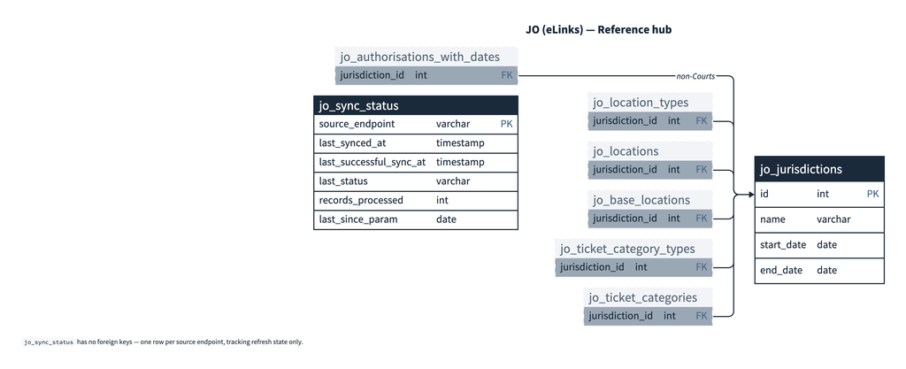

Reference hub ER diagram

## Full ER diagram

All 16 tables on one canvas — transactional, reference and sync:

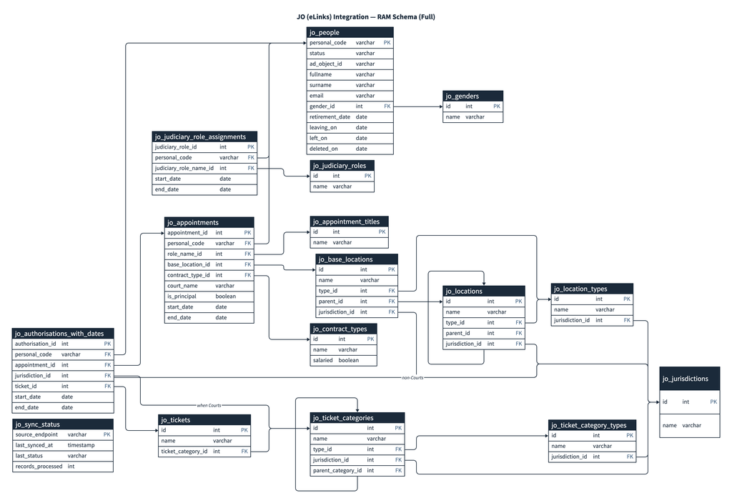

Full ER diagram